# Logistic Regression Help Sheet

Linear regressions allow us to examine relationships between one or more independent variables and a continuous dependent variable. Regression estimates tell us the change in *y* (dependent variable) with every one unit change in *x* (independent variable). Examining a relationship with a dichotomous dependent variable can be a bit trickier. We can’t use a linear model (lm) to fit a model with a dichotomous dependent variable, because we will get y-hats that are values other than 0 and 1 (among other reasons). To analyze a relationship such as this, we must use a generalized linear model (glm), specifically a *logistic regression*, also called a *logit*.

First, let’s read in our data. We’ll be using the correlates dataset once again. The dataset has one observation for each state in the year 2010.

```r
#Reading in the data
correlates2010 <- read.csv("correlates2010.csv")
```

For this example, let’s examine whether or not the state ideology score affects the legality of medical marijuana within a state. Below is a boxplot displaying this relationship so that we can get a sense of the relationship. Remember that higher ideology scores indicate more liberal populations and lower scores indicate the opposite. Already, it appears that there is a slight relationship between state ideologies and the legality of medical marijuana within a state.

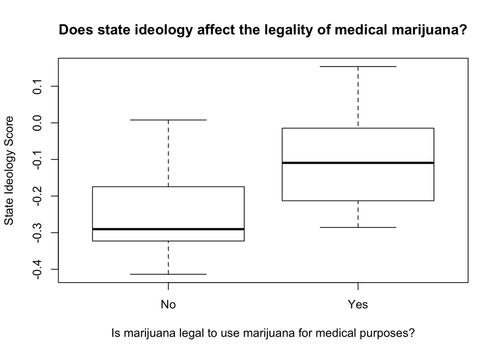

```r
boxplot(correlates2010$ideo ~ correlates2010$drugs_medical_marijua,
        main = "Does state ideology affect the legality of medical marijuana?",
        xlab = "Is marijuana legal to use marijuana for medical purposes?",
        ylab= "State Ideology Score",
        names = c("No","Yes"))
```

Now we are can estimate a logistic regression. We use the `glm()` function, which works the same way that `lm()` does. This regression equation takes the dependent variable, followed by any independent variable, separated by the tilde (~). The function needs to also include the argument `data = correlates2010` to indicate where our data is coming from and `family = "binomial"` to tell R that it should run a logistic regression.

## Running a GLM

Below, we run a logit and assign this object to *regression1*:

```r
regression1 <- glm(drugs_medical_marijua ~ ideo, data = correlates2010, family = "binomial")
summary(regression1)
```

```
##
## Call:
## glm(formula = drugs_medical_marijua ~ ideo, family = "binomial",
##     data = correlates2010)
##
## Deviance Residuals:
##     Min       1Q   Median       3Q      Max
## -1.6232  -0.6813  -0.4510   0.6835   2.0574
##
## Coefficients:
##             Estimate Std. Error z value Pr(>|z|)
## (Intercept)   0.9258     0.6508   1.423  0.15484
## ideo         10.1985     3.2706   3.118  0.00182 **
## ---
## Signif. codes:  0 '***' 0.001 '**' 0.01 '*' 0.05 '.' 0.1 ' ' 1
##
## (Dispersion parameter for binomial family taken to be 1)
##
##     Null deviance: 59.295  on 49  degrees of freedom
## Residual deviance: 45.706  on 48  degrees of freedom
## AIC: 49.706
##
## Number of Fisher Scoring iterations: 5
```

As we can see from the summary of *regression1* above, the summary for a logit looks the same as the output from a linear model That being said, they can’t be interpreted the same way. In this model, we see that the state ideology variable is statistically significant. We find this out in the same way as we did with a linear model: the p-value is less than 0.05. However, the interpretation of the beta-hats is different in a logistic regression. Because the beta-hat is positive (greater than 0), we can determine that there is a positive relationship between the independent variable and the dependent variable: as the state ideology score gets higher, the more likely it is that a state has legalized medical marijuana. However, because the logistic regression estimates a *curve* and not a *line*, we cannot interpret the beta-hat as the effect of a one-unit change in the dependent variable.

# Predicted Probabilities for a Logistic Regression

Predicting values (also called predicted probabilities) for a logistic regression is done in the same way as for linear models. Instead of predicting, like we would with a linear regression, the predicted value of y (what we called a y-hat), we predict the *probability* that the dependent variable is equal to 1 when we make predictions from a logistic regression.

To calculate predicted probabilities, let’s first set up a dataframe with possible state ideology scores. We can use the function `seq()` to create a vector of numbers from -1 to 1, incrementing by 0.05 each iteration. Next, we’ll calculate our predicted probabilities using the `predict()` function, just as we did with linear regression (just remember to include `type="response"` in the `predict()` command). Finally, we’ll plot this prediction.

Here are all of those steps put together:

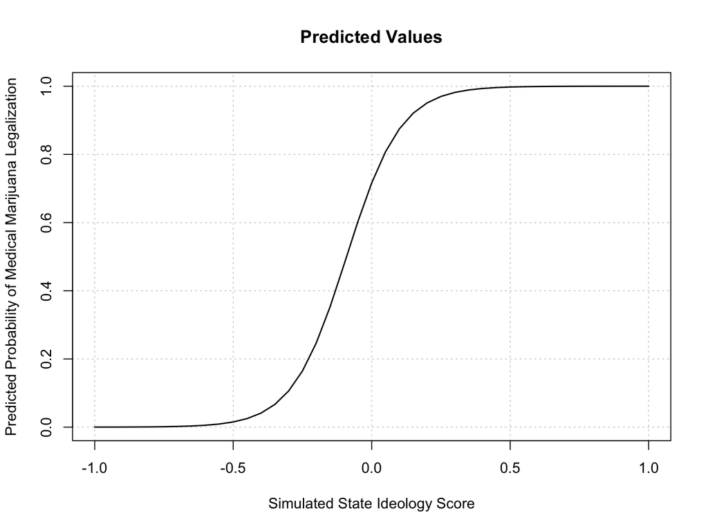

```r
#Making new dataframe of simulated values
new.data1 = data.frame(ideo = seq(-1,1,.05))

#Predicting y-hats
new.data1$prediction1 <- predict(regression1, new.data1, type = "response")

#Plotting predictions vs simulated values
plot(x = new.data1$ideo, y = new.data1$prediction1,
     main = "Predicted Values",
     xlab = "Simulated State Ideology Score",
     ylab = "Predicted Probability of Medical Marijuana Legalization",
     lwd = 1.5,
     type = "l",
     panel.first = grid())
```

## Multivariate GLM

Next, let’s examine a multivariate generalized linear model. Ideology probably isn’t the only thing deciding whether or not a state has legalized medical marijuana. In the model below we examine the effect of state ideology, proportion of Democrats in the state house, the number of residents aged 25 to 44, and the population within a state that have no health insurance on whether or not a state has legalized medical marijuana.

Here is this GLM:

```r
regression2 <- glm(drugs_medical_marijua ~ ideo + hs_dem_prop_all + pop25to44 + popnohealthins, data = correlates2010, family = "binomial")
summary(regression2)
```

```
##
## Call:
## glm(formula = drugs_medical_marijua ~ ideo + hs_dem_prop_all +
##     pop25to44 + popnohealthins, family = "binomial", data = correlates2010)
##
## Deviance Residuals:
##     Min       1Q   Median       3Q      Max
## -1.5810  -0.5945  -0.3803   0.4415   1.9955
##
## Coefficients:
##                   Estimate Std. Error z value Pr(>|z|)
## (Intercept)      7.441e-01  2.576e+00   0.289  0.77272
## ideo             1.227e+01  4.700e+00   2.609  0.00907 **
## hs_dem_prop_all  2.023e+00  3.396e+00   0.596  0.55131
## pop25to44       -1.695e-06  8.936e-07  -1.897  0.05782 .
## popnohealthins   2.272e-03  1.214e-03   1.872  0.06121 .
## ---
## Signif. codes:  0 '***' 0.001 '**' 0.01 '*' 0.05 '.' 0.1 ' ' 1
##
## (Dispersion parameter for binomial family taken to be 1)
##
##     Null deviance: 58.630  on 48  degrees of freedom
## Residual deviance: 41.411  on 44  degrees of freedom
##   (1 observation deleted due to missingness)
## AIC: 51.411
##
## Number of Fisher Scoring iterations: 5
```

## Multivariate Prediction Plot

Let’s examine how the proportion of state house seats held by Democrats affects the predicted probability of marijuana legalization. In the example below we’ll examine what the regression model looks like when the proportion of state house seats held by Democrats is at its 25th and 75th percentile values. We’ll hold all other variables at their mean, and again have ideology vary from -1 to 1. We will follow the same steps that we used in the previous section, except this plot will include two lines.

Below I highlight each step on how to create a two line prediction plot:

```r
#First, making a dataframe with low simulated proportion of state house seats held by democrats (25th percentile value) while ideology varies
summary(correlates2010$hs_dem_prop_all)
```

```
##    Min. 1st Qu.  Median    Mean 3rd Qu.    Max.    NA's
##  0.2571  0.4500  0.5667  0.5549  0.6358  0.9200       1
```

[figure not shown]

```r
new.data2 = data.frame(ideo = seq(-1,1,.05),
                       hs_dem_prop_all = 0.4500,
                       pop25to44 = mean(correlates2010$pop25to44),
                       popnohealthins = mean(correlates2010$popnohealthins))

#Predicted probabilities with first dataframe
new.data2$prediction <- predict(regression2, new.data2, type = "response")


#Next, making a dataframe with high simulated proportion of state house seats held by democrats (75th percentile) while ideology varies
new.data3 = data.frame(ideo = seq(-1,1,.05),
                       hs_dem_prop_all = 0.6358,
                       pop25to44 = mean(correlates2010$pop25to44),
                       popnohealthins = mean(correlates2010$popnohealthins))

#Predicted probabilities with second dataframe
new.data3$prediction <- predict(regression2, new.data3, type = "response")


#Plotting the y-hats of the first prediction
plot(x = seq(-1,1,.05), y = new.data2$prediction,
     main = "Predicted Values",
     xlab = "State Ideology Score",
     ylab = "Predicted Probability of Medical Marijuana Legalization",
     type = "l",
     ylim = c(0,1),
     cex = 1.5,
     col = "red",
     panel.first = grid())

#Plotting the y-hats of the second prediction
lines(x = seq(-1,1,.05), y = new.data3$prediction, col = "blue", lty = 2)

#Adding a legend
legend("bottomright", lty = c(1,2), col = c("red", "blue"), legend = c("High Democratic Control of State House","Low Democratic Control of State House"))
```

## Examining Coefficients with coefplot

Remember, if you’ve never used this function before, use *install.packages(“coefplot”)* to install it:

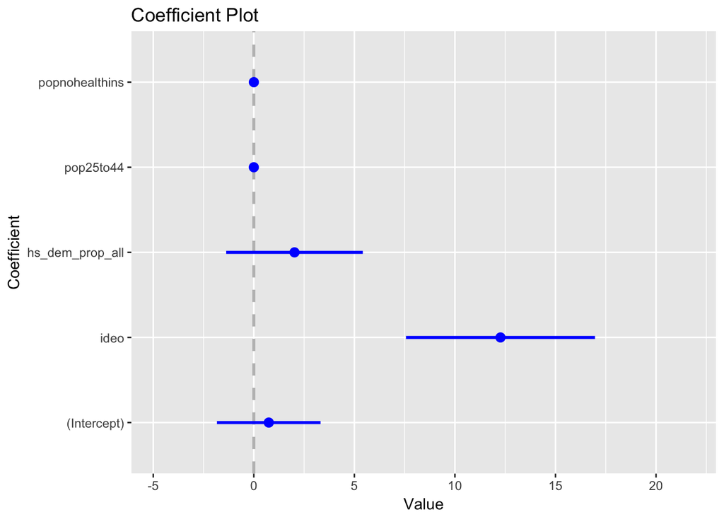

```r
#Calling the coefplot library and running  a plot with the second regression
library(coefplot)
coefplot(regression2, intercept = TRUE)
```

## Viewing More Than One Regression at Once

Stargazer is one of the best functions in R to make regressions easy to read. Often we’ll want to examine more than one regression at a time though. When that is the case, we can put multiple regressions into the *stargazer()* function to print them.

Below is an example of using stargazer to print the previous regressions in one table. It is important that when labeling the variables in the regressions, they are put in order within the *covariate.labels* argument.

Here it is:

```r
library(stargazer)
stargazer(regression1, regression2,
          type = "text",
          dep.var.labels = c("Legalization of Medical Marijuana"),
          covariate.labels = c("State Ideology Score", "Proportion of House Democrats", "Population Aged 25 to 44", "Population Without Health Insurance"))
```

```
##
## ======================================================================
##                                            Dependent variable:
##                                     ----------------------------------
##                                     Legalization of Medical Marijuana
##                                            (1)              (2)
## ----------------------------------------------------------------------
## State Ideology Score                    10.199***        12.265***
##                                          (3.271)          (4.700)
##
## Proportion of House Democrats                              2.023
##                                                           (3.396)
##
## Population Aged 25 to 44                                 -0.00000*
##                                                          (0.00000)
##
## Population Without Health Insurance                        0.002*
##                                                           (0.001)
##
## Constant                                  0.926            0.744
##                                          (0.651)          (2.576)
##
## ----------------------------------------------------------------------
## Observations                               50                49
## Log Likelihood                           -22.853          -20.706
## Akaike Inf. Crit.                        49.706            51.411
## ======================================================================
## Note:                                      *p<0.1; **p<0.05; ***p<0.01
```

This regression table is easy to read and helps to visualize the differences in our models. First, we notice that the State Ideology Score is statistically significant across both models in terms of predicating whether or not a state has legalized medical marijuana. The other thing we notics is that the population aged 25 to 44 and the population without health insurance are only statistically significant in the 2nd model at the 0.1 alpha level.

Helpsheet made by Jacob Ryan.